# Ecommerce Customers Data Analysis and Clustering

## Defining the Question

### 1.1 Specifying the Question

To be able to observe characteristics exhibited by different groups of Kira Plastinina customers.

### 1.2 Defining the Metrics of Success

To consider my analysis successful I should have been able to group customers that exhibit similar characteristics together and point out their observable characteristics.

### 1.3 Context

The data was collected over an year by Sales and marketing team from the ecommerce website. It consists of 12330 records and 18 variables; 10 of which contain numerical data while the other eight contain categorical data.

These variables include:

- Administrative - number of admin pages visited by customer
- Administrative duration - total time spent on pages
- Informational - number of info pages visited by customer
- Informational duration - total time spent on pages
- Product related - number of product pages visited by customer
- Product related duration - total time spent on pages
- Bounce rate - percentage of visitors that left the site without triggering any other requests from the site
- Exit rate - computed by last page/total pages visited. Higher exit rates indicate that the current page is likely to be the last and lower exit rates indicate the opposite.
- Page value - the average value for a web page that a user visited before completing an e-commerce transaction.
- Special day - the closeness of the site visiting time to a specific special day i.e Valentine’s day, in which the sessions are more likely to be finalized with the transaction.
- Month - month of the year
- Operating systems - the operating system used
- Browser - browser used to visit site
- Region - region where customer resides
- Traffic type - type of traffic
- Visitor type - either returning or new visitor
- Weekend - whether the day was a weekend or not
- Revenue - whether the customer made a purchase or not

## Loading and Checking the data

```r
# loading and previewing my data set
shoppers <- read_csv("online_shoppers_intention.csv", show_col_types = FALSE)
head(shoppers)
```

```
## # A tibble: 6 x 18
##   Administrative Administrative_D~ Informational Informational_D~ ProductRelated
##            <dbl>             <dbl>         <dbl>            <dbl>          <dbl>
## 1              0                 0             0                0              1
## 2              0                 0             0                0              2
## 3              0                -1             0               -1              1
## 4              0                 0             0                0              2
## 5              0                 0             0                0             10
## 6              0                 0             0                0             19
## # ... with 13 more variables: ProductRelated_Duration <dbl>, BounceRates <dbl>,
## #   ExitRates <dbl>, PageValues <dbl>, SpecialDay <dbl>, Month <chr>,
## #   OperatingSystems <dbl>, Browser <dbl>, Region <dbl>, TrafficType <dbl>,
## #   VisitorType <chr>, Weekend <lgl>, Revenue <lgl>
```

```r
# checking the bottom of the data frame
tail(shoppers)
```

```
## # A tibble: 6 x 18
##   Administrative Administrative_D~ Informational Informational_D~ ProductRelated
##            <dbl>             <dbl>         <dbl>            <dbl>          <dbl>
## 1              0                 0             1                0             16
## 2              3               145             0                0             53
## 3              0                 0             0                0              5
## 4              0                 0             0                0              6
## 5              4                75             0                0             15
## 6              0                 0             0                0              3
## # ... with 13 more variables: ProductRelated_Duration <dbl>, BounceRates <dbl>,
## #   ExitRates <dbl>, PageValues <dbl>, SpecialDay <dbl>, Month <chr>,
## #   OperatingSystems <dbl>, Browser <dbl>, Region <dbl>, TrafficType <dbl>,
## #   VisitorType <chr>, Weekend <lgl>, Revenue <lgl>
```

```r
# checking the number of columns and rows in my data frame
dim(shoppers)
```

```
## [1] 12330    18
```

The data comprises of 12330 rows and 18 columns.

```r
# displaying the column specifications for my data
spec(shoppers)
```

[output not shown]

A majority of the columns in the data frame are numeric while two have character data and two contain logical data. Traffic type, operating systems, browser and region are categorical variables that have been encoded.

## Data cleaning

```r
# checking for missing data
colSums(is.na(shoppers))
```

```
##          Administrative Administrative_Duration           Informational
##                      14                      14                      14
##  Informational_Duration          ProductRelated ProductRelated_Duration
##                      14                      14                      14
##             BounceRates               ExitRates              PageValues
##                      14                      14                       0
##              SpecialDay                   Month        OperatingSystems
##                       0                       0                       0
##                 Browser                  Region             TrafficType
##                       0                       0                       0
##             VisitorType                 Weekend                 Revenue
##                       0                       0                       0
```

There are 8 columns with 14 missing values each. It is highly likely the missing values occur in the same 14 records. As 14 is a small number relative to 12330, I will simply drop the records with missing values.

```r
# dropping records with missing values
Shoppers <- na.omit(shoppers)
dim(Shoppers)
```

```
## [1] 12316    18
```

```r
# checking for duplicated data
Shoppers[duplicated(Shoppers), ]
```

```
## # A tibble: 117 x 18
##    Administrative Administrative_~ Informational Informational_D~ ProductRelated
##             <dbl>            <dbl>         <dbl>            <dbl>          <dbl>
##  1              0                0             0                0              1
##  2              0                0             0                0              1
##  3              0                0             0                0              1
##  4              0                0             0                0              1
##  5              0                0             0                0              1
##  6              0                0             0                0              1
##  7              0                0             0                0              1
##  8              0                0             0                0              1
##  9              0                0             0                0              2
## 10              0                0             0                0              1
## # ... with 107 more rows, and 13 more variables: ProductRelated_Duration <dbl>,
## #   BounceRates <dbl>, ExitRates <dbl>, PageValues <dbl>, SpecialDay <dbl>,
## #   Month <chr>, OperatingSystems <dbl>, Browser <dbl>, Region <dbl>,
## #   TrafficType <dbl>, VisitorType <chr>, Weekend <lgl>, Revenue <lgl>
```

```r
# removing records with duplicated data

Shoppers <- distinct(Shoppers)
Shoppers[duplicated(Shoppers), ]
```

```
## # A tibble: 0 x 18
## # ... with 18 variables: Administrative <dbl>, Administrative_Duration <dbl>,
## #   Informational <dbl>, Informational_Duration <dbl>, ProductRelated <dbl>,
## #   ProductRelated_Duration <dbl>, BounceRates <dbl>, ExitRates <dbl>,
## #   PageValues <dbl>, SpecialDay <dbl>, Month <chr>, OperatingSystems <dbl>,
## #   Browser <dbl>, Region <dbl>, TrafficType <dbl>, VisitorType <chr>,
## #   Weekend <lgl>, Revenue <lgl>
```

There are no more duplicates in my data.

```r
# converting my encoded categorical variables to factors

Shoppers$Region <- factor(Shoppers$Region)
Shoppers$TrafficType <- factor(Shoppers$TrafficType)
Shoppers$Browser <- factor(Shoppers$Browser)
Shoppers$OperatingSystems <- factor(Shoppers$OperatingSystems)
Shoppers$Month <- factor(Shoppers$Month)
```

```r
# checking for anomalies in my categorical data and some numerical data columns

unique(Shoppers$Weekend)
```

```
## [1] FALSE  TRUE
```

```r
unique(Shoppers$Month)
```

```
##  [1] Feb  Mar  May  Oct  June Jul  Aug  Nov  Sep  Dec
## Levels: Aug Dec Feb Jul June Mar May Nov Oct Sep
```

```r
unique(Shoppers$VisitorType)
```

```
## [1] "Returning_Visitor" "New_Visitor"       "Other"
```

```r
unique(Shoppers$Revenue)
```

```
## [1] FALSE  TRUE
```

```r
unique(Shoppers$TrafficType)
```

```
##  [1] 1  2  3  4  5  6  7  8  9  10 11 12 13 14 15 18 19 16 17 20
## Levels: 1 2 3 4 5 6 7 8 9 10 11 12 13 14 15 16 17 18 19 20
```

```r
unique(Shoppers$Region)
```

```
## [1] 1 9 2 3 4 5 6 7 8
## Levels: 1 2 3 4 5 6 7 8 9
```

```r
unique(Shoppers$Browser)
```

```
##  [1] 1  2  3  4  5  6  7  10 8  9  12 13 11
## Levels: 1 2 3 4 5 6 7 8 9 10 11 12 13
```

```r
unique(Shoppers$OperatingSystems)
```

```
## [1] 1 2 4 3 7 6 8 5
## Levels: 1 2 3 4 5 6 7 8
```

```r
range(Shoppers$BounceRates)
```

```
## [1] 0.0 0.2
```

```r
range(Shoppers$ExitRates)
```

```
## [1] 0.0 0.2
```

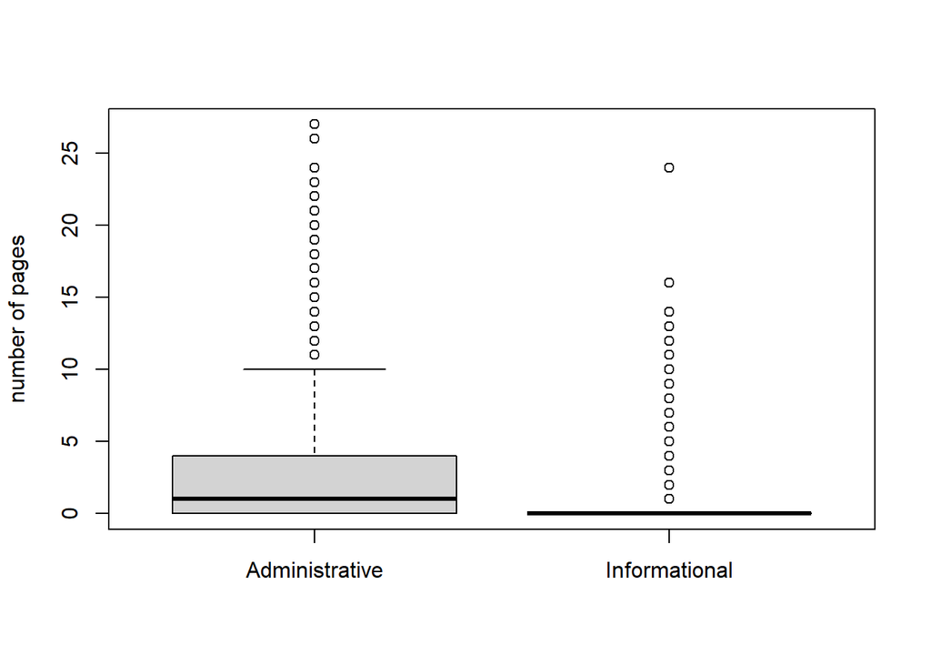

```r
# checking for outliers
pages <- Shoppers[ ,c("Administrative","Informational")]
durations <- Shoppers[ ,c("Administrative_Duration","Informational_Duration")]

boxplot(pages, ylab ="number of pages")
```

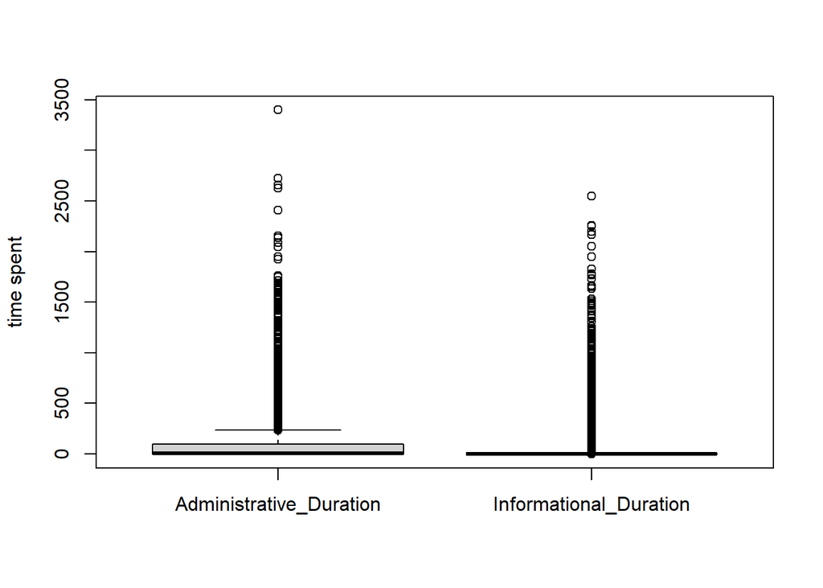

```r
boxplot(durations, ylab ="time spent")
```

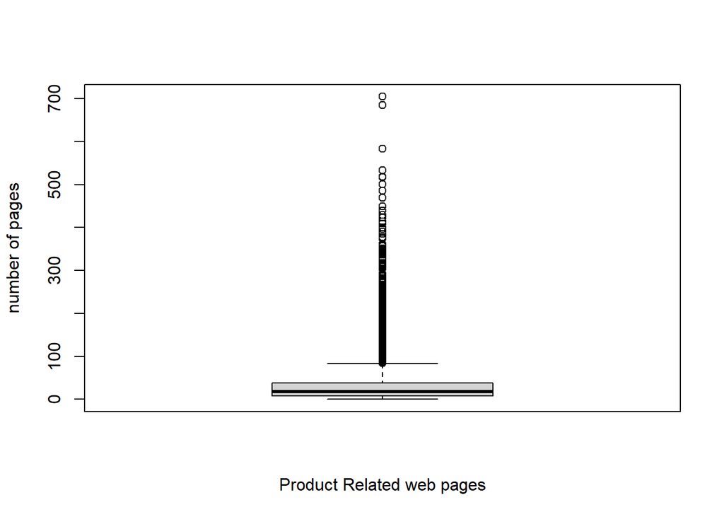

```r
boxplot(Shoppers$ProductRelated, ylab ="number of pages", xlab = "Product Related web pages")
```

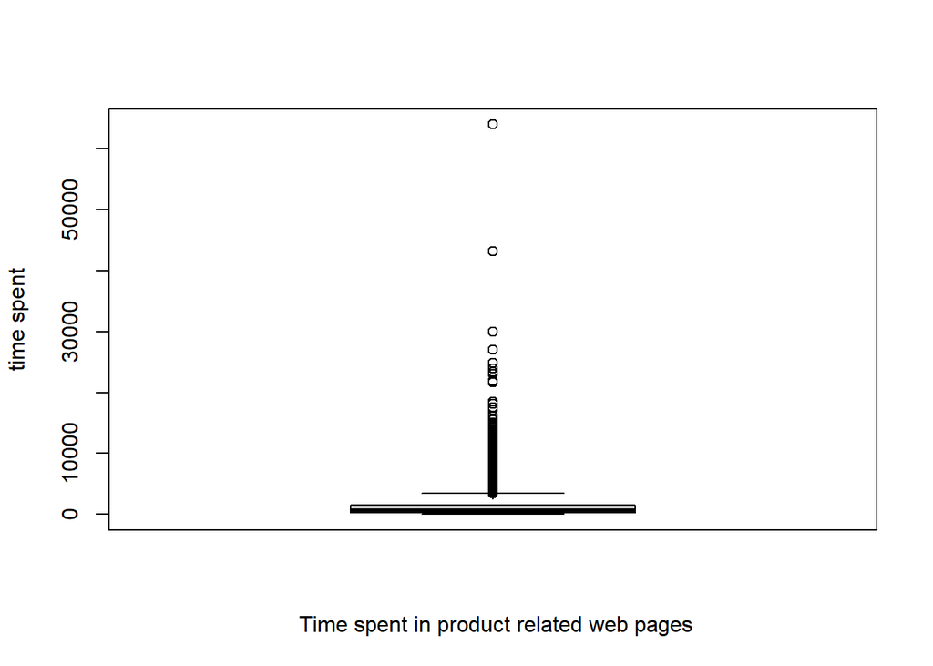

```r
boxplot(Shoppers$ProductRelated_Duration, ylab ="time spent", xlab =" Time spent in product related web pages")
```

- There are quite a bit of outliers in the variables Administrative and Informational, so much so that I cannot get rid of the outliers.
- The administrative web pages appear to have been visited more frequently in comparison to the informational web pages.
- The administrative and informational duration also exhibit the presence of a lot of outliers. The time spent on administrative web pages also appears to be more.
- The number of web pages visited that are product related are way higher than for both informational and administrative web pages. The presence of many outliers is also observed in this variable.
- The time spent on product related web pages is also higher in comparison to time spent in both informational and administrative web pages. Many outliers are also present in this variable.

## Exploratory data analysis

### 4.1 Univariate Analysis

```r
# displaying the summary statistics for my quantitative variables
quantitative <- Shoppers[ ,c("Administrative","Administrative_Duration","Informational","Informational_Duration"
                             ,"ProductRelated","ProductRelated_Duration","BounceRates","ExitRates","PageValues","SpecialDay")]

summary(quantitative)
```

```
##  Administrative  Administrative_Duration Informational
##  Min.   : 0.00   Min.   :  -1.00         Min.   : 0.0000
##  1st Qu.: 0.00   1st Qu.:   0.00         1st Qu.: 0.0000
##  Median : 1.00   Median :   9.00         Median : 0.0000
##  Mean   : 2.34   Mean   :  81.68         Mean   : 0.5088
##  3rd Qu.: 4.00   3rd Qu.:  94.75         3rd Qu.: 0.0000
##  Max.   :27.00   Max.   :3398.75         Max.   :24.0000
##  Informational_Duration ProductRelated   ProductRelated_Duration
##  Min.   :  -1.00        Min.   :  0.00   Min.   :   -1.0
##  1st Qu.:   0.00        1st Qu.:  8.00   1st Qu.:  193.6
##  Median :   0.00        Median : 18.00   Median :  609.5
##  Mean   :  34.84        Mean   : 32.06   Mean   : 1207.5
##  3rd Qu.:   0.00        3rd Qu.: 38.00   3rd Qu.: 1477.6
##  Max.   :2549.38        Max.   :705.00   Max.   :63973.5
##   BounceRates        ExitRates         PageValues        SpecialDay
##  Min.   :0.00000   Min.   :0.00000   Min.   :  0.000   Min.   :0.00000
##  1st Qu.:0.00000   1st Qu.:0.01422   1st Qu.:  0.000   1st Qu.:0.00000
##  Median :0.00293   Median :0.02500   Median :  0.000   Median :0.00000
##  Mean   :0.02045   Mean   :0.04150   Mean   :  5.952   Mean   :0.06197
##  3rd Qu.:0.01667   3rd Qu.:0.04848   3rd Qu.:  0.000   3rd Qu.:0.00000
##  Max.   :0.20000   Max.   :0.20000   Max.   :361.764   Max.   :1.00000
```

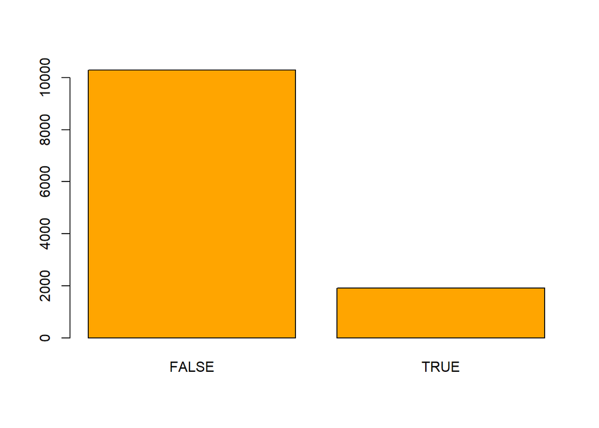

```r
# plotting the number of people who made a purchase and those who did not
revenue.table <- table(Shoppers$Revenue)
barplot(revenue.table, col ="orange")
```

The number of visitors that did not make a purchase is significantly larger than those that did make a purchase from the site.

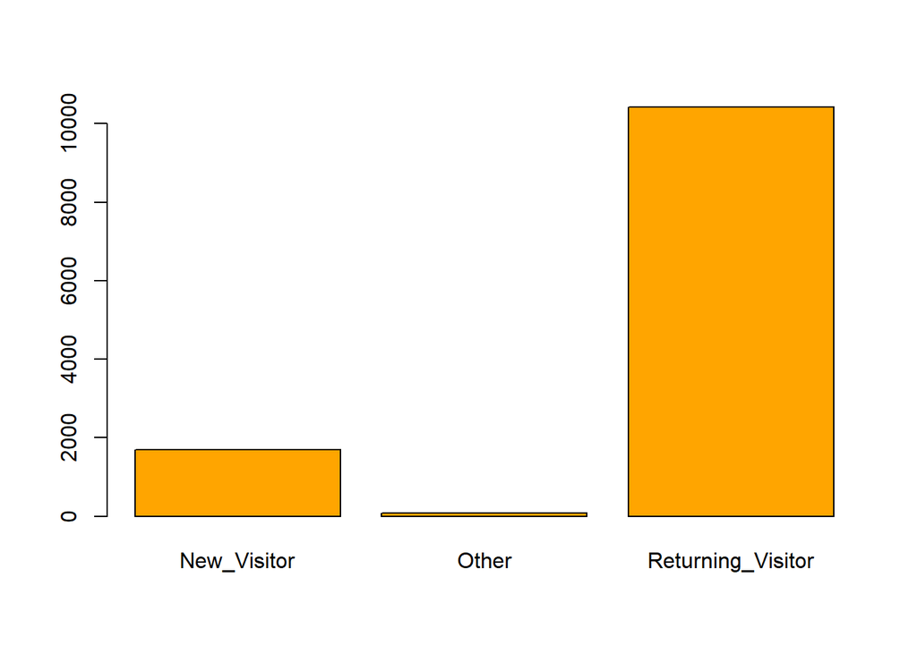

```r
# plotting the numbers of visitor types
visitor.table <- table(Shoppers$VisitorType)
barplot(visitor.table, col = "orange")
```

A majority of the visitors to the site had been to the site before.

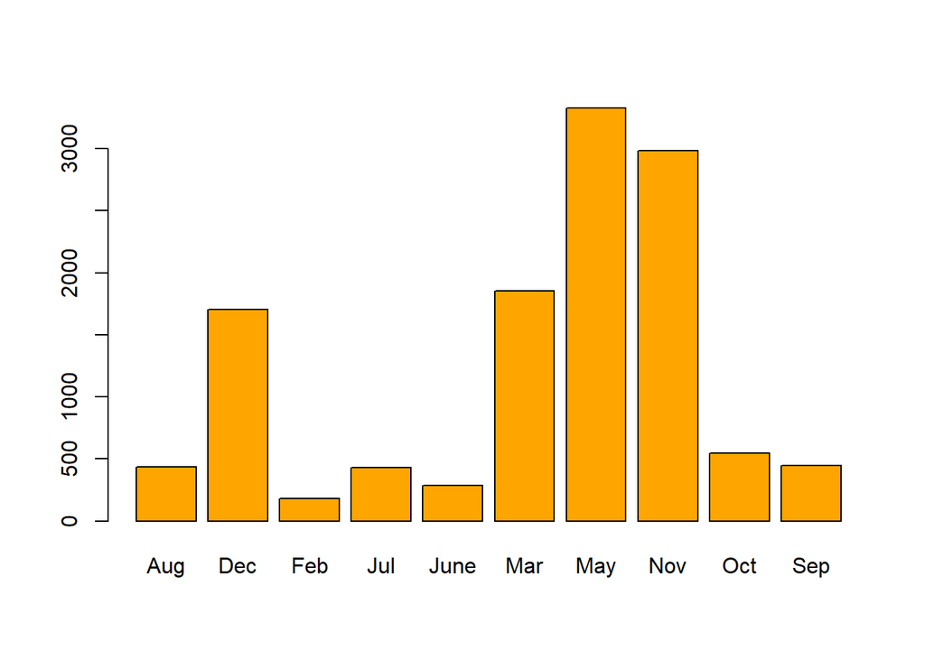

```r
# plotting the number of visitors for the different months
month.table <- table(Shoppers$Month)
barplot(month.table, col = "orange")
```

The months of May and November appear to have had the highest number of visitors that year followed by March and December respectively. The month that recorded the least number of visitors was February.

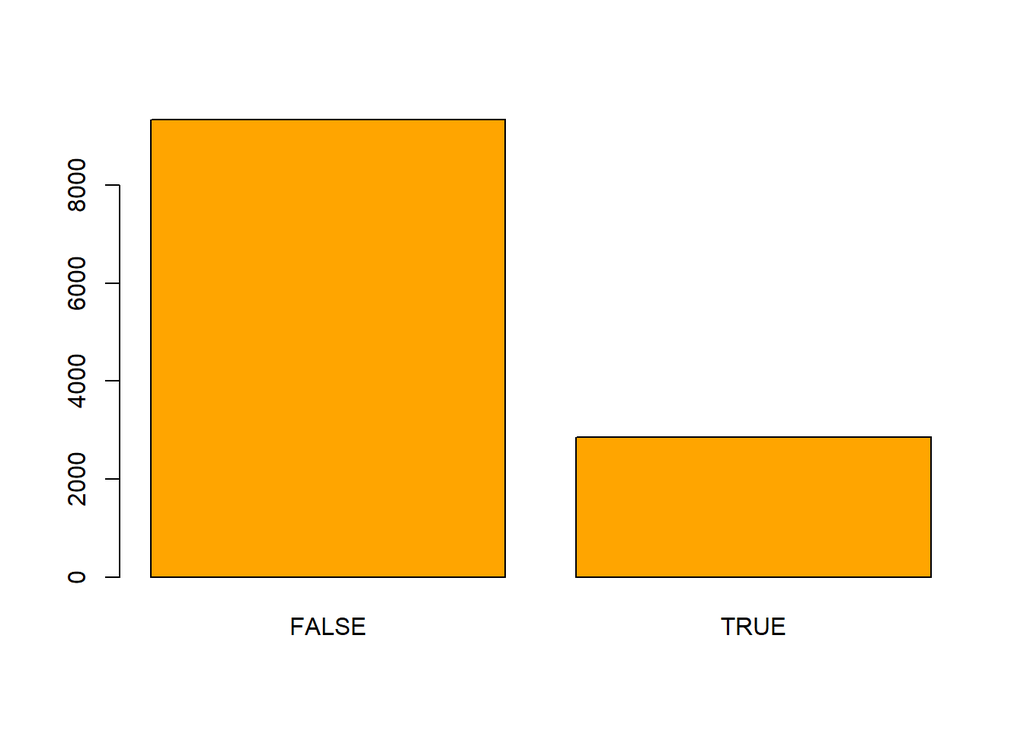

```r
# plotting the number of visitors during the weekdays and weekends
week.table <- table(Shoppers$Weekend)
barplot(week.table, col = "orange")
```

A majority of the visiting of the site occurred during weekdays.

```r
# plotting the distributions for the quantitative variables.
par(mfrow = c(5,2), cex = 1.6)

i = 1
for (x in quantitative){
  hist(x, col ="orange", xlab = names(Shoppers)[i])
  i <- i + 1
}
```

[figure not shown]

### 4.2 Bi-variate Analysis

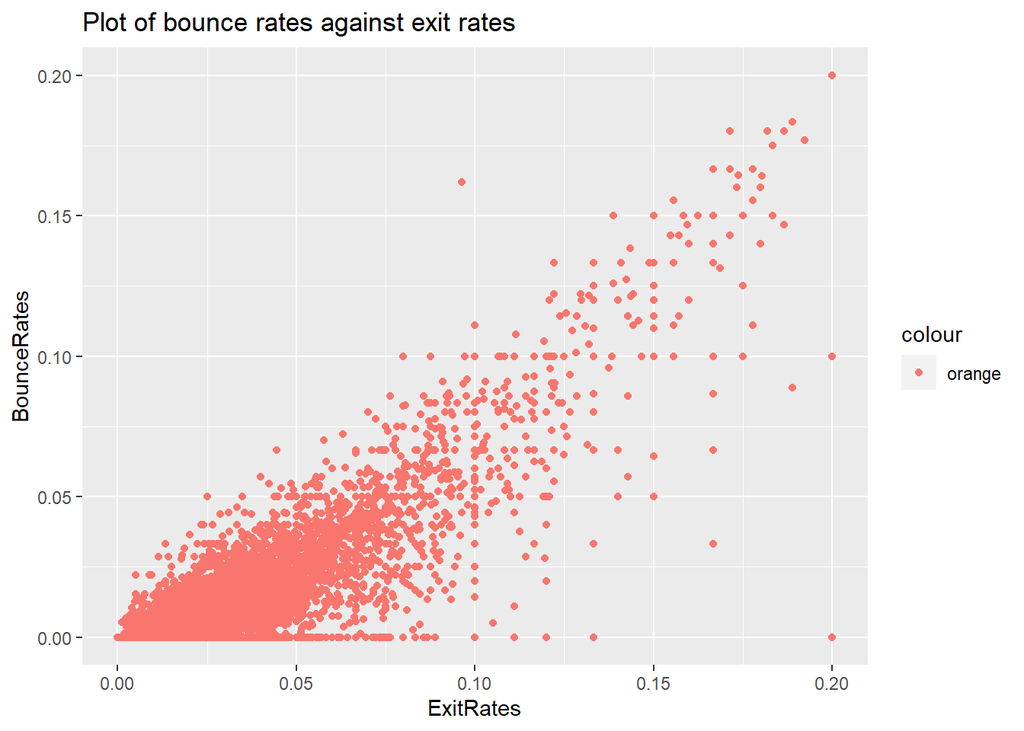

```r
qplot(ExitRates,
      BounceRates,
      data = Shoppers,
      main = "Plot of bounce rates against exit rates",
      colour = "orange"
      )
```

There appears to be a direct correlation between exit rates and bounce rates.

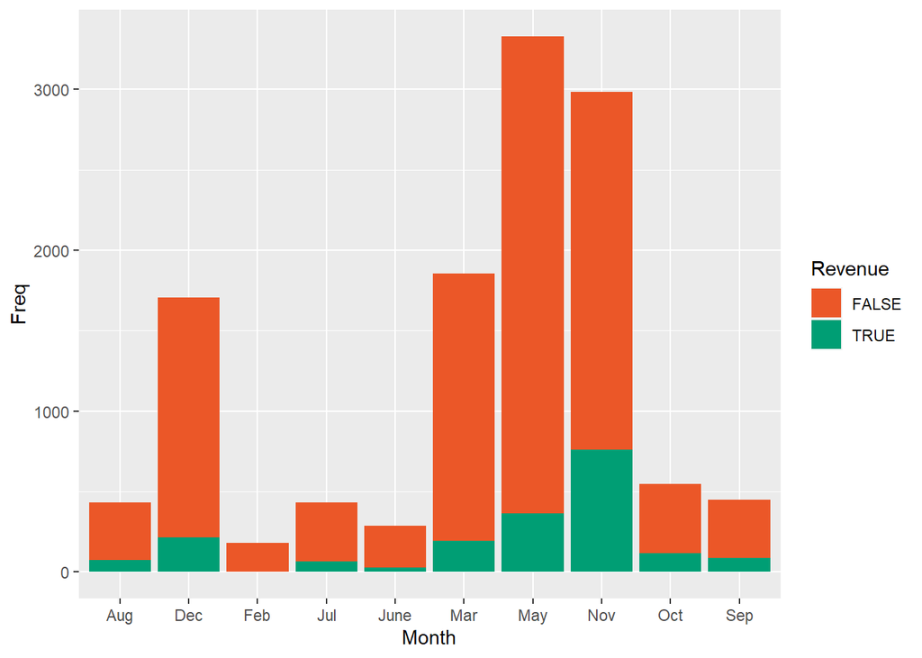

```r
# plotting the number of visitors that made a purchase each month

visitor_month <- Shoppers[ , c("Month", "Revenue")]
df <- data.frame(table(visitor_month))


ggplot(data = df, aes(Month, Freq, fill = Revenue)) + geom_bar(position="stack", stat="identity") + scale_fill_manual(values=c("#EB5728","#009E74"))
```

November has the highest number of visitors that made a purchase from the website and February the least with barely any visitors making a purchase.

### 4.3 Multivariate Analysis

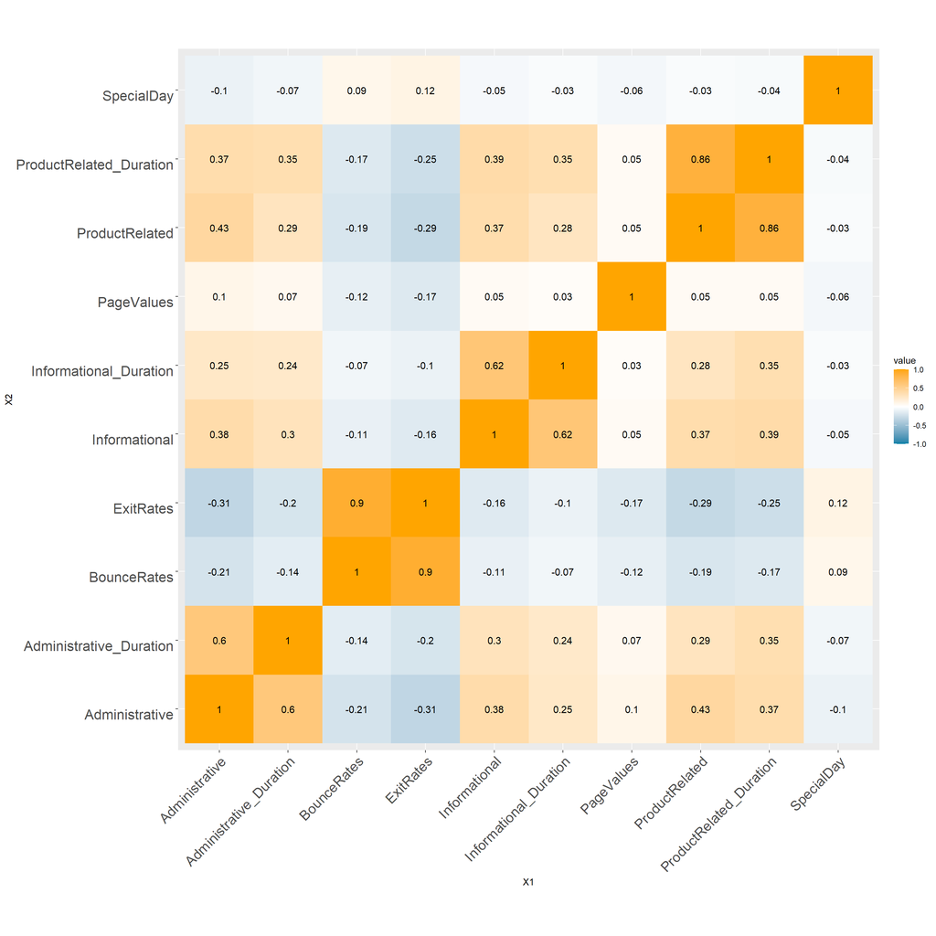

```r
# plotting the correlations of my variables

correlations <- round(cor(quantitative), 2)

# melting the correlations
melted <- melt(correlations, na.rm=FALSE)

# Plotting the correlation heat map
ggplot(data = melted, aes(X1, X2, fill=value)) + geom_tile() +scale_fill_gradient2(low = "#0081A8", high = "orange", mid = "white",
   midpoint = 0, limit = c(-1,1)) + geom_text(aes(X1, X2, label = value), color = "black", size = 4) +theme(axis.text.x = element_text(angle = 45, vjust = 1,
    size = 16, hjust = 1), axis.text.y = element_text(vjust = 1, size = 16, hjust = 1))+
 coord_fixed()
```

The elements that exhibit high correlations to each other include:

- Bounce rates and exit rates
- ProductRelated and Productrelated_Duration
- Informational and Informational_Duration
- Administrative and Administrative_Duration

```r
# picking the month variable and the time spent on the different web pages
durations <- Shoppers[ , c("Month", "Administrative_Duration", "Informational_Duration", "ProductRelated_Duration")]

# previewing the head
head(durations)
```

```
## # A tibble: 6 x 4
##   Month Administrative_Duration Informational_Duration ProductRelated_Duration
##   <fct>                   <dbl>                  <dbl>                   <dbl>
## 1 Feb                         0                      0                    0
## 2 Feb                         0                      0                   64
## 3 Feb                        -1                     -1                   -1
## 4 Feb                         0                      0                    2.67
## 5 Feb                         0                      0                  628.
## 6 Feb                         0                      0                  154.
```

```r
# obtaining the summations of time spent for the different months
summer <- durations %>% group_by(Month) %>% summarise(across(everything(), sum))
summer
```

```
## # A tibble: 10 x 4
##    Month Administrative_Duration Informational_Duration ProductRelated_Duration
##    <fct>                   <dbl>                  <dbl>                   <dbl>
##  1 Aug                    46209.                 15378.                 551059.
##  2 Dec                   135799.                 65746.                1919510.
##  3 Feb                     3092.                   426                   86654.
##  4 Jul                    34073.                 19664.                 526004.
##  5 June                   17029.                  5890.                 349453.
##  6 Mar                   135828.                 58454.                1548221.
##  7 May                   233677.                 91371.                3303079.
##  8 Nov                   272615.                130815.                5271674.
##  9 Oct                    69141.                 21228.                 613221.
## 10 Sep                    48978.                 16010.                 561518.
```

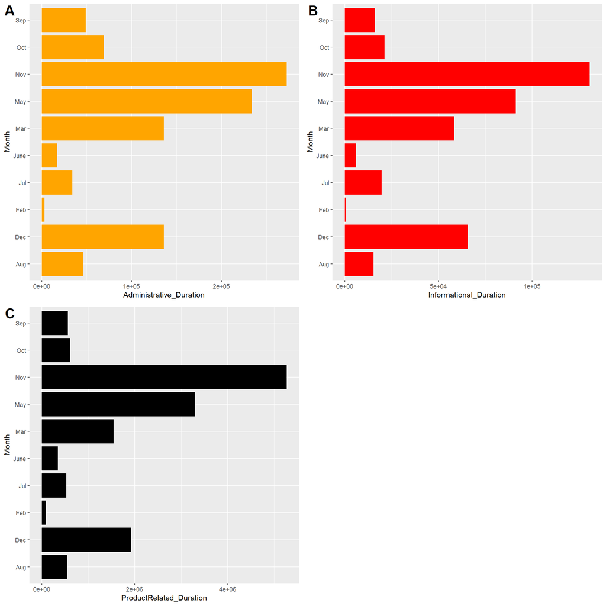

```r
# plotting my bar graphs

AD <- ggplot(summer, aes(x=Month, y=Administrative_Duration)) + geom_bar(stat = "identity", fill = "orange") + coord_flip()
ID <- ggplot(summer, aes(x=Month, y=Informational_Duration)) + geom_bar(stat = "identity", fill = "red") + coord_flip()
PRD <- ggplot(summer, aes(x=Month, y=ProductRelated_Duration)) + geom_bar(stat = "identity", fill = "black") + coord_flip()

plot_grid(AD, ID, PRD, labels = "AUTO", label_size = 20)
```

* The durations spent for the different web pages appear to have fluctuated in th same way.

## Implementing the solution

The clustering method, I will put to use first will be Hierarchical clustering. As some of my quantitative variable exhibit presence of outliers, using this method the outliers will be easy to spot.

```r
# Measuring distance for categorical variables
categorical <- Shoppers[ , c("TrafficType", "OperatingSystems", "Browser", "Weekend", "Region", "Month", "Revenue")]
is.factor(Shoppers$Month)
```

```
## [1] TRUE
```

```r
cat_dist <- daisy(categorical, metric = c("gower"))
```

```r
# clustering
cat_clust <- as.dendrogram(hclust(cat_dist, method = "complete"))
plot(cat_clust, cex = 2, xlab = "Height", horiz = TRUE)
```

[figure not shown]

```r
# scaling my quantitative variable data frame
scaled <- scale(quantitative)

# computing distance
dq <- dist(scaled, method = "euclidean")

# clustering
clusters <- as.dendrogram(hclust(dq, method = "complete"))

# plotting dendrogram
plot(clusters, cex = 2, xlab = "Height", horiz= TRUE)
```

[figure not shown]

Hierarchical clustering is not the best when dealing with a large data set. As I made use of agglomeration method, my dendrogram appears very congested at the bottom and barely readable.

## Challenging the solution

The DBSCAN clustering might be a better algorithm to use as it is more robust in dealng with outliers and can handle large sets of data.

```r
# clustering using db scan

library("dbscan")
db_cluster <- dbscan(quantitative, eps = 30, minPts =50)
print(db_cluster)
```

```
## DBSCAN clustering for 12199 objects.
## Parameters: eps = 30, minPts = 50
## The clustering contains 2 cluster(s) and 6191 noise points.
##
##    0    1    2
## 6191 5819  189
##
## Available fields: cluster, eps, minPts
```

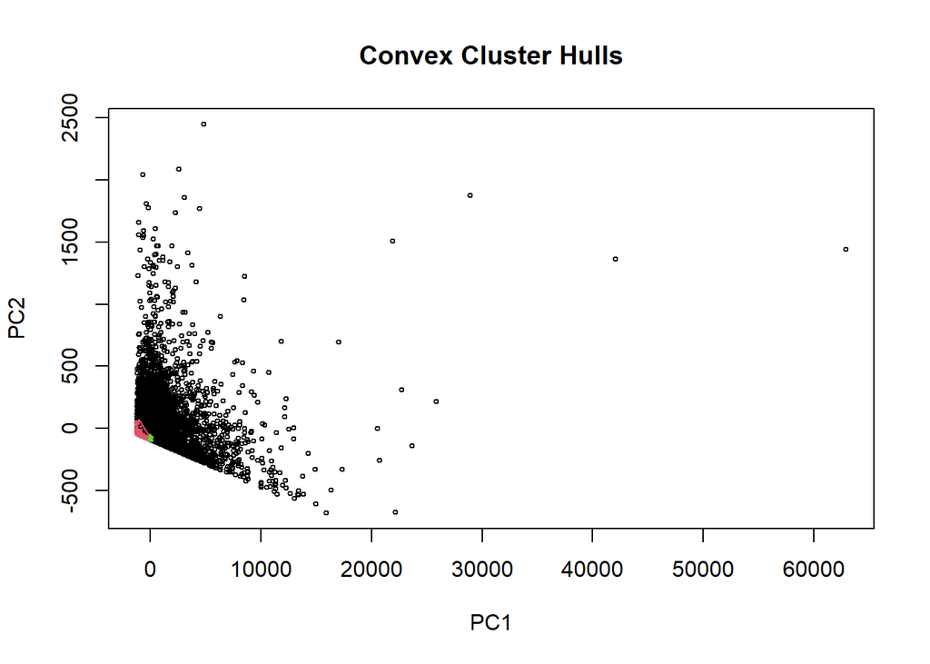

```r
# plotting the hull plot
hullplot(quantitative, db_cluster$cluster)
```

The algorithm created 2 clusters of 5819 and 189 data points. 6191 were classified as noise.